# Risk Factor Analysis

## Outcome Variable

**Outcome Variable:** ever_stunted

## Predictor Variables

**Intervention Variable:** feducyrs

**Adjustment Set:**

unadjusted

## Stratifying Variables

The analysis was stratified on these variable(s):

- agecat
- studyid
- country

## Data Summary

| agecat | studyid | country | feducyrs | ever_stunted | n_cell | n |
| --- | --- | --- | --- | --- | --- | --- |
| 0-6 months | ki0047075b-MAL-ED | BANGLADESH | Q4 | 0 | 46 | 149 |
| 0-6 months | ki0047075b-MAL-ED | BANGLADESH | Q4 | 1 | 8 | 149 |
| 0-6 months | ki0047075b-MAL-ED | BANGLADESH | Q1 | 0 | 25 | 149 |
| 0-6 months | ki0047075b-MAL-ED | BANGLADESH | Q1 | 1 | 6 | 149 |
| 0-6 months | ki0047075b-MAL-ED | BANGLADESH | Q2 | 0 | 6 | 149 |
| 0-6 months | ki0047075b-MAL-ED | BANGLADESH | Q2 | 1 | 3 | 149 |
| 0-6 months | ki0047075b-MAL-ED | BANGLADESH | Q3 | 0 | 45 | 149 |
| 0-6 months | ki0047075b-MAL-ED | BANGLADESH | Q3 | 1 | 10 | 149 |
| 0-6 months | ki0047075b-MAL-ED | INDIA | Q4 | 0 | 36 | 147 |
| 0-6 months | ki0047075b-MAL-ED | INDIA | Q4 | 1 | 8 | 147 |
| 0-6 months | ki0047075b-MAL-ED | INDIA | Q1 | 0 | 24 | 147 |
| 0-6 months | ki0047075b-MAL-ED | INDIA | Q1 | 1 | 1 | 147 |
| 0-6 months | ki0047075b-MAL-ED | INDIA | Q2 | 0 | 39 | 147 |
| 0-6 months | ki0047075b-MAL-ED | INDIA | Q2 | 1 | 6 | 147 |
| 0-6 months | ki0047075b-MAL-ED | INDIA | Q3 | 0 | 28 | 147 |
| 0-6 months | ki0047075b-MAL-ED | INDIA | Q3 | 1 | 5 | 147 |
| 0-6 months | ki0047075b-MAL-ED | NEPAL | Q4 | 0 | 37 | 98 |
| 0-6 months | ki0047075b-MAL-ED | NEPAL | Q4 | 1 | 5 | 98 |
| 0-6 months | ki0047075b-MAL-ED | NEPAL | Q1 | 0 | 21 | 98 |
| 0-6 months | ki0047075b-MAL-ED | NEPAL | Q1 | 1 | 3 | 98 |
| 0-6 months | ki0047075b-MAL-ED | NEPAL | Q2 | 0 | 19 | 98 |
| 0-6 months | ki0047075b-MAL-ED | NEPAL | Q2 | 1 | 6 | 98 |
| 0-6 months | ki0047075b-MAL-ED | NEPAL | Q3 | 0 | 6 | 98 |
| 0-6 months | ki0047075b-MAL-ED | NEPAL | Q3 | 1 | 1 | 98 |
| 0-6 months | ki0047075b-MAL-ED | PERU | Q4 | 0 | 109 | 250 |
| 0-6 months | ki0047075b-MAL-ED | PERU | Q4 | 1 | 11 | 250 |
| 0-6 months | ki0047075b-MAL-ED | PERU | Q1 | 0 | 40 | 250 |
| 0-6 months | ki0047075b-MAL-ED | PERU | Q1 | 1 | 11 | 250 |
| 0-6 months | ki0047075b-MAL-ED | PERU | Q2 | 0 | 59 | 250 |
| 0-6 months | ki0047075b-MAL-ED | PERU | Q2 | 1 | 7 | 250 |

[output cut: 446 more lines]

The following strata were considered:

- agecat: 0-24 months, studyid: ki0047075b-MAL-ED, country: BANGLADESH
- agecat: 0-24 months, studyid: ki0047075b-MAL-ED, country: INDIA
- agecat: 0-24 months, studyid: ki0047075b-MAL-ED, country: NEPAL
- agecat: 0-24 months, studyid: ki0047075b-MAL-ED, country: PERU
- agecat: 0-24 months, studyid: ki0047075b-MAL-ED, country: SOUTH AFRICA
- agecat: 0-24 months, studyid: ki0047075b-MAL-ED, country: TANZANIA, UNITED REPUBLIC OF
- agecat: 0-24 months, studyid: ki1000304b-SAS-CompFeed, country: INDIA
- agecat: 0-24 months, studyid: ki1000304b-SAS-FoodSuppl, country: INDIA
- agecat: 0-24 months, studyid: ki1017093b-PROVIDE, country: BANGLADESH
- agecat: 0-24 months, studyid: ki1017093c-NIH-Crypto, country: BANGLADESH
- agecat: 0-24 months, studyid: ki1066203-TanzaniaChild2, country: TANZANIA, UNITED REPUBLIC OF
- agecat: 0-24 months, studyid: ki1113344-GMS-Nepal, country: NEPAL
- agecat: 0-24 months, studyid: ki1119695-PROBIT, country: BELARUS
- agecat: 0-24 months, studyid: ki1126311-ZVITAMBO, country: ZIMBABWE
- agecat: 0-24 months, studyid: ki1135781-COHORTS, country: GUATEMALA
- agecat: 0-24 months, studyid: ki1135781-COHORTS, country: INDIA
- agecat: 0-24 months, studyid: ki1135781-COHORTS, country: PHILIPPINES
- agecat: 0-24 months, studyid: ki1148112-LCNI-5, country: MALAWI
- agecat: 0-24 months, studyid: kiGH5241-JiVitA-3, country: BANGLADESH
- agecat: 0-24 months, studyid: kiGH5241-JiVitA-4, country: BANGLADESH
- agecat: 0-6 months, studyid: ki0047075b-MAL-ED, country: BANGLADESH
- agecat: 0-6 months, studyid: ki0047075b-MAL-ED, country: INDIA
- agecat: 0-6 months, studyid: ki0047075b-MAL-ED, country: NEPAL
- agecat: 0-6 months, studyid: ki0047075b-MAL-ED, country: PERU
- agecat: 0-6 months, studyid: ki0047075b-MAL-ED, country: SOUTH AFRICA
- agecat: 0-6 months, studyid: ki0047075b-MAL-ED, country: TANZANIA, UNITED REPUBLIC OF
- agecat: 0-6 months, studyid: ki1000304b-SAS-CompFeed, country: INDIA
- agecat: 0-6 months, studyid: ki1000304b-SAS-FoodSuppl, country: INDIA
- agecat: 0-6 months, studyid: ki1017093b-PROVIDE, country: BANGLADESH
- agecat: 0-6 months, studyid: ki1017093c-NIH-Crypto, country: BANGLADESH
- agecat: 0-6 months, studyid: ki1066203-TanzaniaChild2, country: TANZANIA, UNITED REPUBLIC OF
- agecat: 0-6 months, studyid: ki1113344-GMS-Nepal, country: NEPAL
- agecat: 0-6 months, studyid: ki1119695-PROBIT, country: BELARUS
- agecat: 0-6 months, studyid: ki1126311-ZVITAMBO, country: ZIMBABWE
- agecat: 0-6 months, studyid: ki1135781-COHORTS, country: GUATEMALA
- agecat: 0-6 months, studyid: ki1135781-COHORTS, country: INDIA
- agecat: 0-6 months, studyid: ki1135781-COHORTS, country: PHILIPPINES
- agecat: 0-6 months, studyid: ki1148112-LCNI-5, country: MALAWI
- agecat: 0-6 months, studyid: kiGH5241-JiVitA-3, country: BANGLADESH
- agecat: 0-6 months, studyid: kiGH5241-JiVitA-4, country: BANGLADESH
- agecat: 6-24 months, studyid: ki0047075b-MAL-ED, country: BANGLADESH
- agecat: 6-24 months, studyid: ki0047075b-MAL-ED, country: INDIA
- agecat: 6-24 months, studyid: ki0047075b-MAL-ED, country: NEPAL
- agecat: 6-24 months, studyid: ki0047075b-MAL-ED, country: PERU
- agecat: 6-24 months, studyid: ki0047075b-MAL-ED, country: SOUTH AFRICA
- agecat: 6-24 months, studyid: ki0047075b-MAL-ED, country: TANZANIA, UNITED REPUBLIC OF
- agecat: 6-24 months, studyid: ki1000304b-SAS-CompFeed, country: INDIA
- agecat: 6-24 months, studyid: ki1000304b-SAS-FoodSuppl, country: INDIA
- agecat: 6-24 months, studyid: ki1017093b-PROVIDE, country: BANGLADESH
- agecat: 6-24 months, studyid: ki1017093c-NIH-Crypto, country: BANGLADESH
- agecat: 6-24 months, studyid: ki1066203-TanzaniaChild2, country: TANZANIA, UNITED REPUBLIC OF
- agecat: 6-24 months, studyid: ki1113344-GMS-Nepal, country: NEPAL
- agecat: 6-24 months, studyid: ki1119695-PROBIT, country: BELARUS
- agecat: 6-24 months, studyid: ki1126311-ZVITAMBO, country: ZIMBABWE
- agecat: 6-24 months, studyid: ki1135781-COHORTS, country: GUATEMALA
- agecat: 6-24 months, studyid: ki1135781-COHORTS, country: INDIA
- agecat: 6-24 months, studyid: ki1135781-COHORTS, country: PHILIPPINES
- agecat: 6-24 months, studyid: ki1148112-LCNI-5, country: MALAWI
- agecat: 6-24 months, studyid: kiGH5241-JiVitA-3, country: BANGLADESH
- agecat: 6-24 months, studyid: kiGH5241-JiVitA-4, country: BANGLADESH

### Dropped Strata

Some strata were dropped due to rare outcomes:

## Methods Detail

We’re interested in the causal parameters $E[Y_a]$ for all values of $a \in \mathcal{A}$. These parameters represent the mean outcome if, possibly contrary to fact, we intervened to set all units to have $A=a$. Under the randomization and positivity assumptions, these are identified by the statistical parameters $\psi_a=E_W[E_{Y|A,W}(Y|A=a,W)]$. In addition, we’re interested in the mean of $Y$, $E[Y]$ under no intervention (the observed mean). We will estimate these parameters by using SuperLearner to fit the relevant likelihood factors – $E_{Y|A,W}(Y|A=a,W)$ and $p(A=a|W)$, and then updating our likelihood fit using a joint TMLE.

For unadjusted analyses ($W=\{\}$), initial likelihoods were estimated using Lrnr_glm to estimate the simple $E(Y|A)$ and Lrnr_mean to estimate $p(A)$. For adjusted analyses, a small library containing Lrnr_glmnet, Lrnr_xgboost, and Lrnr_mean was used.

Having estimated these parameters, we will then use the delta method to estimate relative risks and attributable risks relative to a prespecified baseline level of $A$.

```
##         ever_stunted
## feducyrs   0
##       Q4 359
##       Q1 176
##       Q2 163
##       Q3 463
```

# Results Detail

## Results Plots

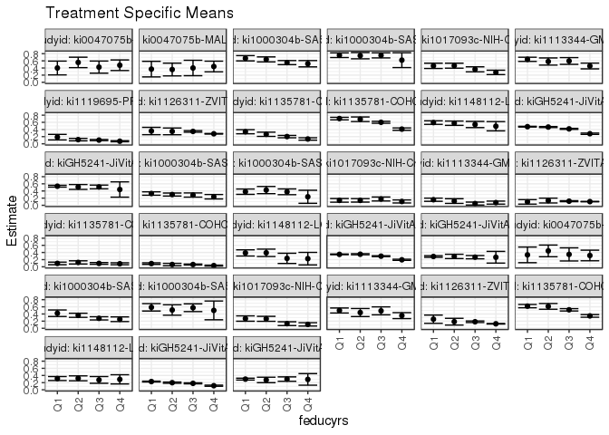

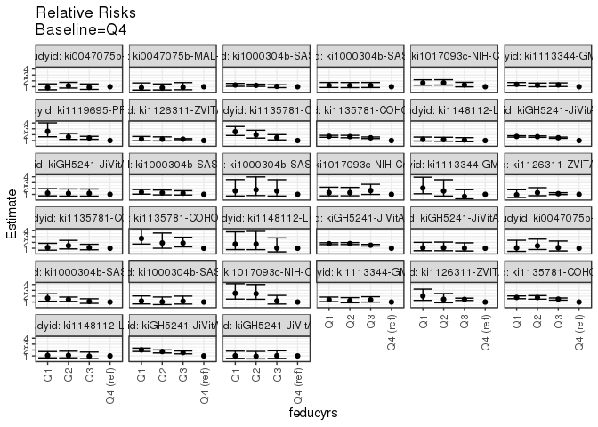

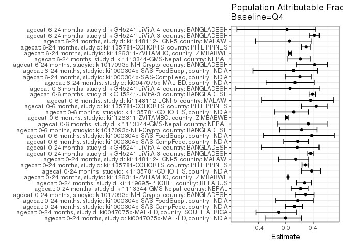

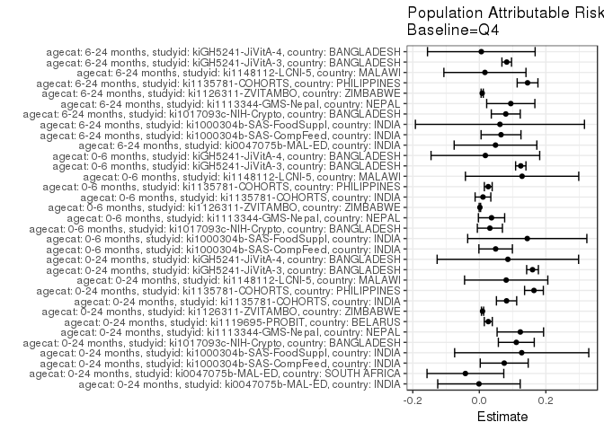

## Results Table

### Parameter: TSM

| agecat | studyid | country | intervention_level | baseline_level | estimate | ci_lower | ci_upper |
| --- | --- | --- | --- | --- | --- | --- | --- |
| 0-24 months | ki0047075b-MAL-ED | INDIA | Q4 | NA | 0.4772727 | 0.3291830 | 0.6253624 |
| 0-24 months | ki0047075b-MAL-ED | INDIA | Q1 | NA | 0.4000000 | 0.2073070 | 0.5926930 |
| 0-24 months | ki0047075b-MAL-ED | INDIA | Q2 | NA | 0.5555556 | 0.4098767 | 0.7012344 |
| 0-24 months | ki0047075b-MAL-ED | INDIA | Q3 | NA | 0.4242424 | 0.2550425 | 0.5934424 |
| 0-24 months | ki0047075b-MAL-ED | SOUTH AFRICA | Q4 | NA | 0.4418605 | 0.2927490 | 0.5909719 |
| 0-24 months | ki0047075b-MAL-ED | SOUTH AFRICA | Q1 | NA | 0.3684211 | 0.1505295 | 0.5863126 |
| 0-24 months | ki0047075b-MAL-ED | SOUTH AFRICA | Q2 | NA | 0.3571429 | 0.1788515 | 0.5354343 |
| 0-24 months | ki0047075b-MAL-ED | SOUTH AFRICA | Q3 | NA | 0.4000000 | 0.1843141 | 0.6156859 |
| 0-24 months | ki1000304b-SAS-CompFeed | INDIA | Q4 | NA | 0.5192802 | 0.4310977 | 0.6074628 |
| 0-24 months | ki1000304b-SAS-CompFeed | INDIA | Q1 | NA | 0.6721311 | 0.5982064 | 0.7460559 |
| 0-24 months | ki1000304b-SAS-CompFeed | INDIA | Q2 | NA | 0.6398964 | 0.5700148 | 0.7097780 |
| 0-24 months | ki1000304b-SAS-CompFeed | INDIA | Q3 | NA | 0.5501285 | 0.4931656 | 0.6070915 |
| 0-24 months | ki1000304b-SAS-FoodSuppl | INDIA | Q4 | NA | 0.6190476 | 0.4110991 | 0.8269962 |
| 0-24 months | ki1000304b-SAS-FoodSuppl | INDIA | Q1 | NA | 0.7575758 | 0.6921080 | 0.8230435 |
| 0-24 months | ki1000304b-SAS-FoodSuppl | INDIA | Q2 | NA | 0.7446809 | 0.6564275 | 0.8329342 |
| 0-24 months | ki1000304b-SAS-FoodSuppl | INDIA | Q3 | NA | 0.7536232 | 0.6816442 | 0.8256022 |
| 0-24 months | ki1017093c-NIH-Crypto | BANGLADESH | Q4 | NA | 0.2766990 | 0.2155676 | 0.3378304 |
| 0-24 months | ki1017093c-NIH-Crypto | BANGLADESH | Q1 | NA | 0.4597701 | 0.3856698 | 0.5338704 |
| 0-24 months | ki1017093c-NIH-Crypto | BANGLADESH | Q2 | NA | 0.4642857 | 0.3944197 | 0.5341517 |
| 0-24 months | ki1017093c-NIH-Crypto | BANGLADESH | Q3 | NA | 0.3626374 | 0.2927452 | 0.4325296 |
| 0-24 months | ki1113344-GMS-Nepal | NEPAL | Q4 | NA | 0.4557823 | 0.3752044 | 0.5363602 |
| 0-24 months | ki1113344-GMS-Nepal | NEPAL | Q1 | NA | 0.6420233 | 0.5833628 | 0.7006839 |
| 0-24 months | ki1113344-GMS-Nepal | NEPAL | Q2 | NA | 0.5806452 | 0.4802727 | 0.6810176 |
| 0-24 months | ki1113344-GMS-Nepal | NEPAL | Q3 | NA | 0.5961538 | 0.5017738 | 0.6905339 |
| 0-24 months | ki1119695-PROBIT | BELARUS | Q4 | NA | 0.0720355 | 0.0565520 | 0.0875189 |
| 0-24 months | ki1119695-PROBIT | BELARUS | Q1 | NA | 0.1851852 | 0.1081278 | 0.2622426 |
| 0-24 months | ki1119695-PROBIT | BELARUS | Q2 | NA | 0.1171662 | 0.0826666 | 0.1516659 |
| 0-24 months | ki1119695-PROBIT | BELARUS | Q3 | NA | 0.1038371 | 0.0872993 | 0.1203750 |
| 0-24 months | ki1126311-ZVITAMBO | ZIMBABWE | Q4 | NA | 0.2799693 | 0.2718376 | 0.2881009 |
| 0-24 months | ki1126311-ZVITAMBO | ZIMBABWE | Q1 | NA | 0.3571429 | 0.2546715 | 0.4596142 |

[output cut: 102 more lines]

### Parameter: E(Y)

| agecat | studyid | country | intervention_level | baseline_level | estimate | ci_lower | ci_upper |
| --- | --- | --- | --- | --- | --- | --- | --- |
| 0-24 months | ki0047075b-MAL-ED | INDIA | NA | NA | 0.4761905 | 0.3951786 | 0.5572024 |
| 0-24 months | ki0047075b-MAL-ED | SOUTH AFRICA | NA | NA | 0.4000000 | 0.3080312 | 0.4919688 |
| 0-24 months | ki1000304b-SAS-CompFeed | INDIA | NA | NA | 0.5941176 | 0.5531511 | 0.6350842 |
| 0-24 months | ki1000304b-SAS-FoodSuppl | INDIA | NA | NA | 0.7464115 | 0.7046540 | 0.7881689 |
| 0-24 months | ki1017093c-NIH-Crypto | BANGLADESH | NA | NA | 0.3878628 | 0.3531521 | 0.4225735 |
| 0-24 months | ki1113344-GMS-Nepal | NEPAL | NA | NA | 0.5790349 | 0.5395303 | 0.6185396 |
| 0-24 months | ki1119695-PROBIT | BELARUS | NA | NA | 0.0989947 | 0.0831753 | 0.1148141 |
| 0-24 months | ki1126311-ZVITAMBO | ZIMBABWE | NA | NA | 0.2895640 | 0.2819669 | 0.2971611 |
| 0-24 months | ki1135781-COHORTS | INDIA | NA | NA | 0.2163096 | 0.1950882 | 0.2375310 |
| 0-24 months | ki1135781-COHORTS | PHILIPPINES | NA | NA | 0.5743056 | 0.5562443 | 0.5923668 |
| 0-24 months | ki1148112-LCNI-5 | MALAWI | NA | NA | 0.5719557 | 0.5379231 | 0.6059884 |
| 0-24 months | kiGH5241-JiVitA-3 | BANGLADESH | NA | NA | 0.4414466 | 0.4338889 | 0.4490043 |
| 0-24 months | kiGH5241-JiVitA-4 | BANGLADESH | NA | NA | 0.5269656 | 0.5048164 | 0.5491148 |
| 0-6 months | ki1000304b-SAS-CompFeed | INDIA | NA | NA | 0.2881467 | 0.2614090 | 0.3148844 |
| 0-6 months | ki1000304b-SAS-FoodSuppl | INDIA | NA | NA | 0.3822115 | 0.3354600 | 0.4289631 |
| 0-6 months | ki1017093c-NIH-Crypto | BANGLADESH | NA | NA | 0.1385224 | 0.1139141 | 0.1631308 |
| 0-6 months | ki1113344-GMS-Nepal | NEPAL | NA | NA | 0.1114809 | 0.0862979 | 0.1366638 |
| 0-6 months | ki1126311-ZVITAMBO | ZIMBABWE | NA | NA | 0.1048051 | 0.0996708 | 0.1099394 |
| 0-6 months | ki1135781-COHORTS | INDIA | NA | NA | 0.0957072 | 0.0804059 | 0.1110086 |
| 0-6 months | ki1135781-COHORTS | PHILIPPINES | NA | NA | 0.0604167 | 0.0517136 | 0.0691198 |
| 0-6 months | ki1148112-LCNI-5 | MALAWI | NA | NA | 0.3558052 | 0.2982716 | 0.4133389 |
| 0-6 months | kiGH5241-JiVitA-3 | BANGLADESH | NA | NA | 0.3202185 | 0.3133886 | 0.3270484 |
| 0-6 months | kiGH5241-JiVitA-4 | BANGLADESH | NA | NA | 0.2848297 | 0.2655018 | 0.3041577 |
| 6-24 months | ki0047075b-MAL-ED | INDIA | NA | NA | 0.3644068 | 0.2772025 | 0.4516111 |
| 6-24 months | ki1000304b-SAS-CompFeed | INDIA | NA | NA | 0.3187954 | 0.2885259 | 0.3490649 |
| 6-24 months | ki1000304b-SAS-FoodSuppl | INDIA | NA | NA | 0.5619469 | 0.4971181 | 0.6267757 |
| 6-24 months | ki1017093c-NIH-Crypto | BANGLADESH | NA | NA | 0.1887097 | 0.1578857 | 0.2195336 |
| 6-24 months | ki1113344-GMS-Nepal | NEPAL | NA | NA | 0.4488518 | 0.4042636 | 0.4934400 |
| 6-24 months | ki1126311-ZVITAMBO | ZIMBABWE | NA | NA | 0.1343481 | 0.1273279 | 0.1413683 |
| 6-24 months | ki1135781-COHORTS | PHILIPPINES | NA | NA | 0.4911779 | 0.4697758 | 0.5125799 |
| 6-24 months | ki1148112-LCNI-5 | MALAWI | NA | NA | 0.3084922 | 0.2707734 | 0.3462110 |
| 6-24 months | kiGH5241-JiVitA-3 | BANGLADESH | NA | NA | 0.1965318 | 0.1884248 | 0.2046388 |
| 6-24 months | kiGH5241-JiVitA-4 | BANGLADESH | NA | NA | 0.2962963 | 0.2730810 | 0.3195116 |

### Parameter: RR

| agecat | studyid | country | intervention_level | baseline_level | estimate | ci_lower | ci_upper |
| --- | --- | --- | --- | --- | --- | --- | --- |
| 0-24 months | ki0047075b-MAL-ED | INDIA | Q4 | Q4 | 1.0000000 | 1.0000000 | 1.000000 |
| 0-24 months | ki0047075b-MAL-ED | INDIA | Q1 | Q4 | 0.8380952 | 0.4725391 | 1.486446 |
| 0-24 months | ki0047075b-MAL-ED | INDIA | Q2 | Q4 | 1.1640212 | 0.7754082 | 1.747396 |
| 0-24 months | ki0047075b-MAL-ED | INDIA | Q3 | Q4 | 0.8888889 | 0.5362823 | 1.473335 |
| 0-24 months | ki0047075b-MAL-ED | SOUTH AFRICA | Q4 | Q4 | 1.0000000 | 1.0000000 | 1.000000 |
| 0-24 months | ki0047075b-MAL-ED | SOUTH AFRICA | Q1 | Q4 | 0.8337950 | 0.4220242 | 1.647332 |
| 0-24 months | ki0047075b-MAL-ED | SOUTH AFRICA | Q2 | Q4 | 0.8082707 | 0.4424472 | 1.476564 |
| 0-24 months | ki0047075b-MAL-ED | SOUTH AFRICA | Q3 | Q4 | 0.9052632 | 0.4791997 | 1.710146 |
| 0-24 months | ki1000304b-SAS-CompFeed | INDIA | Q4 | Q4 | 1.0000000 | 1.0000000 | 1.000000 |
| 0-24 months | ki1000304b-SAS-CompFeed | INDIA | Q1 | Q4 | 1.2943516 | 1.0678545 | 1.568890 |
| 0-24 months | ki1000304b-SAS-CompFeed | INDIA | Q2 | Q4 | 1.2322757 | 1.0591371 | 1.433717 |
| 0-24 months | ki1000304b-SAS-CompFeed | INDIA | Q3 | Q4 | 1.0594059 | 0.8408537 | 1.334764 |
| 0-24 months | ki1000304b-SAS-FoodSuppl | INDIA | Q4 | Q4 | 1.0000000 | 1.0000000 | 1.000000 |
| 0-24 months | ki1000304b-SAS-FoodSuppl | INDIA | Q1 | Q4 | 1.2237762 | 0.8650973 | 1.731167 |
| 0-24 months | ki1000304b-SAS-FoodSuppl | INDIA | Q2 | Q4 | 1.2029460 | 0.8424543 | 1.717694 |
| 0-24 months | ki1000304b-SAS-FoodSuppl | INDIA | Q3 | Q4 | 1.2173913 | 0.8585409 | 1.726233 |
| 0-24 months | ki1017093c-NIH-Crypto | BANGLADESH | Q4 | Q4 | 1.0000000 | 1.0000000 | 1.000000 |
| 0-24 months | ki1017093c-NIH-Crypto | BANGLADESH | Q1 | Q4 | 1.6616253 | 1.2640571 | 2.184236 |
| 0-24 months | ki1017093c-NIH-Crypto | BANGLADESH | Q2 | Q4 | 1.6779449 | 1.2843582 | 2.192145 |
| 0-24 months | ki1017093c-NIH-Crypto | BANGLADESH | Q3 | Q4 | 1.3105842 | 0.9775454 | 1.757086 |
| 0-24 months | ki1113344-GMS-Nepal | NEPAL | Q4 | Q4 | 1.0000000 | 1.0000000 | 1.000000 |
| 0-24 months | ki1113344-GMS-Nepal | NEPAL | Q1 | Q4 | 1.4086184 | 1.1544273 | 1.718779 |
| 0-24 months | ki1113344-GMS-Nepal | NEPAL | Q2 | Q4 | 1.2739528 | 0.9948794 | 1.631309 |
| 0-24 months | ki1113344-GMS-Nepal | NEPAL | Q3 | Q4 | 1.3079793 | 1.0316592 | 1.658309 |
| 0-24 months | ki1119695-PROBIT | BELARUS | Q4 | Q4 | 1.0000000 | 1.0000000 | 1.000000 |
| 0-24 months | ki1119695-PROBIT | BELARUS | Q1 | Q4 | 2.5707502 | 1.6426942 | 4.023121 |
| 0-24 months | ki1119695-PROBIT | BELARUS | Q2 | Q4 | 1.6265074 | 1.1931637 | 2.217237 |
| 0-24 months | ki1119695-PROBIT | BELARUS | Q3 | Q4 | 1.4414724 | 1.2107301 | 1.716190 |
| 0-24 months | ki1126311-ZVITAMBO | ZIMBABWE | Q4 | Q4 | 1.0000000 | 1.0000000 | 1.000000 |
| 0-24 months | ki1126311-ZVITAMBO | ZIMBABWE | Q1 | Q4 | 1.2756502 | 0.9560643 | 1.702065 |

[output cut: 102 more lines]

### Parameter: PAR

| agecat | studyid | country | intervention_level | baseline_level | estimate | ci_lower | ci_upper |
| --- | --- | --- | --- | --- | --- | --- | --- |
| 0-24 months | ki0047075b-MAL-ED | INDIA | Q4 | NA | -0.0010823 | -0.1250378 | 0.1228733 |
| 0-24 months | ki0047075b-MAL-ED | SOUTH AFRICA | Q4 | NA | -0.0418605 | -0.1572267 | 0.0735057 |
| 0-24 months | ki1000304b-SAS-CompFeed | INDIA | Q4 | NA | 0.0748374 | 0.0027696 | 0.1469053 |
| 0-24 months | ki1000304b-SAS-FoodSuppl | INDIA | Q4 | NA | 0.1273639 | -0.0742331 | 0.3289608 |
| 0-24 months | ki1017093c-NIH-Crypto | BANGLADESH | Q4 | NA | 0.1111638 | 0.0572132 | 0.1651143 |
| 0-24 months | ki1113344-GMS-Nepal | NEPAL | Q4 | NA | 0.1232526 | 0.0534154 | 0.1930899 |
| 0-24 months | ki1119695-PROBIT | BELARUS | Q4 | NA | 0.0269593 | 0.0149083 | 0.0390103 |
| 0-24 months | ki1126311-ZVITAMBO | ZIMBABWE | Q4 | NA | 0.0095947 | 0.0063198 | 0.0128697 |
| 0-24 months | ki1135781-COHORTS | INDIA | Q4 | NA | 0.0818353 | 0.0514071 | 0.1122635 |
| 0-24 months | ki1135781-COHORTS | PHILIPPINES | Q4 | NA | 0.1642336 | 0.1360327 | 0.1924345 |
| 0-24 months | ki1148112-LCNI-5 | MALAWI | Q4 | NA | 0.0807276 | -0.0444026 | 0.2058579 |
| 0-24 months | kiGH5241-JiVitA-3 | BANGLADESH | Q4 | NA | 0.1598898 | 0.1422526 | 0.1775270 |
| 0-24 months | kiGH5241-JiVitA-4 | BANGLADESH | Q4 | NA | 0.0857891 | -0.1268470 | 0.2984252 |
| 0-6 months | ki1000304b-SAS-CompFeed | INDIA | Q4 | NA | 0.0490721 | -0.0012881 | 0.0994324 |
| 0-6 months | ki1000304b-SAS-FoodSuppl | INDIA | Q4 | NA | 0.1441163 | -0.0350240 | 0.3232566 |
| 0-6 months | ki1017093c-NIH-Crypto | BANGLADESH | Q4 | NA | 0.0317263 | -0.0059382 | 0.0693908 |
| 0-6 months | ki1113344-GMS-Nepal | NEPAL | Q4 | NA | 0.0366509 | -0.0028442 | 0.0761460 |
| 0-6 months | ki1126311-ZVITAMBO | ZIMBABWE | Q4 | NA | 0.0016841 | -0.0004999 | 0.0038681 |
| 0-6 months | ki1135781-COHORTS | INDIA | Q4 | NA | 0.0109192 | -0.0127066 | 0.0345451 |
| 0-6 months | ki1135781-COHORTS | PHILIPPINES | Q4 | NA | 0.0268435 | 0.0150682 | 0.0386189 |
| 0-6 months | ki1148112-LCNI-5 | MALAWI | Q4 | NA | 0.1285325 | -0.0418149 | 0.2988799 |
| 0-6 months | kiGH5241-JiVitA-3 | BANGLADESH | Q4 | NA | 0.1245893 | 0.1090628 | 0.1401158 |
| 0-6 months | kiGH5241-JiVitA-4 | BANGLADESH | Q4 | NA | 0.0181631 | -0.1451484 | 0.1814745 |
| 6-24 months | ki0047075b-MAL-ED | INDIA | Q4 | NA | 0.0486173 | -0.0756624 | 0.1728970 |
| 6-24 months | ki1000304b-SAS-CompFeed | INDIA | Q4 | NA | 0.0652240 | 0.0052897 | 0.1251583 |
| 6-24 months | ki1000304b-SAS-FoodSuppl | INDIA | Q4 | NA | 0.0619469 | -0.1921565 | 0.3160503 |
| 6-24 months | ki1017093c-NIH-Crypto | BANGLADESH | Q4 | NA | 0.0795143 | 0.0359968 | 0.1230317 |
| 6-24 months | ki1113344-GMS-Nepal | NEPAL | Q4 | NA | 0.0945211 | 0.0220955 | 0.1669467 |
| 6-24 months | ki1126311-ZVITAMBO | ZIMBABWE | Q4 | NA | 0.0085919 | 0.0053559 | 0.0118279 |
| 6-24 months | ki1135781-COHORTS | PHILIPPINES | Q4 | NA | 0.1449646 | 0.1137730 | 0.1761562 |
| 6-24 months | ki1148112-LCNI-5 | MALAWI | Q4 | NA | 0.0168255 | -0.1065835 | 0.1402346 |
| 6-24 months | kiGH5241-JiVitA-3 | BANGLADESH | Q4 | NA | 0.0823289 | 0.0678906 | 0.0967672 |
| 6-24 months | kiGH5241-JiVitA-4 | BANGLADESH | Q4 | NA | 0.0059737 | -0.1558119 | 0.1677594 |

### Parameter: PAF

| agecat | studyid | country | intervention_level | baseline_level | estimate | ci_lower | ci_upper |
| --- | --- | --- | --- | --- | --- | --- | --- |
| 0-24 months | ki0047075b-MAL-ED | INDIA | Q4 | NA | -0.0022727 | -0.2995095 | 0.2269771 |
| 0-24 months | ki0047075b-MAL-ED | SOUTH AFRICA | Q4 | NA | -0.1046512 | -0.4348364 | 0.1495517 |
| 0-24 months | ki1000304b-SAS-CompFeed | INDIA | Q4 | NA | 0.1259640 | -0.0060334 | 0.2406426 |
| 0-24 months | ki1000304b-SAS-FoodSuppl | INDIA | Q4 | NA | 0.1706349 | -0.1495270 | 0.4016265 |
| 0-24 months | ki1017093c-NIH-Crypto | BANGLADESH | Q4 | NA | 0.2866059 | 0.1332982 | 0.4127955 |
| 0-24 months | ki1113344-GMS-Nepal | NEPAL | Q4 | NA | 0.2128587 | 0.0813348 | 0.3255525 |
| 0-24 months | ki1119695-PROBIT | BELARUS | Q4 | NA | 0.2723303 | 0.1520812 | 0.3755261 |
| 0-24 months | ki1126311-ZVITAMBO | ZIMBABWE | Q4 | NA | 0.0331352 | 0.0217661 | 0.0443721 |
| 0-24 months | ki1135781-COHORTS | INDIA | Q4 | NA | 0.3783248 | 0.2245380 | 0.5016131 |
| 0-24 months | ki1135781-COHORTS | PHILIPPINES | Q4 | NA | 0.2859690 | 0.2343252 | 0.3341296 |
| 0-24 months | ki1148112-LCNI-5 | MALAWI | Q4 | NA | 0.1411432 | -0.1082912 | 0.3344393 |
| 0-24 months | kiGH5241-JiVitA-3 | BANGLADESH | Q4 | NA | 0.3621951 | 0.3213696 | 0.4005646 |
| 0-24 months | kiGH5241-JiVitA-4 | BANGLADESH | Q4 | NA | 0.1627983 | -0.3556221 | 0.4829631 |
| 0-6 months | ki1000304b-SAS-CompFeed | INDIA | Q4 | NA | 0.1703026 | -0.0294698 | 0.3313085 |
| 0-6 months | ki1000304b-SAS-FoodSuppl | INDIA | Q4 | NA | 0.3770590 | -0.3208170 | 0.7062004 |
| 0-6 months | ki1017093c-NIH-Crypto | BANGLADESH | Q4 | NA | 0.2290337 | -0.0937192 | 0.4565434 |
| 0-6 months | ki1113344-GMS-Nepal | NEPAL | Q4 | NA | 0.3287643 | -0.1268546 | 0.6001637 |
| 0-6 months | ki1126311-ZVITAMBO | ZIMBABWE | Q4 | NA | 0.0160689 | -0.0049805 | 0.0366774 |
| 0-6 months | ki1135781-COHORTS | INDIA | Q4 | NA | 0.1140898 | -0.1698643 | 0.3291214 |
| 0-6 months | ki1135781-COHORTS | PHILIPPINES | Q4 | NA | 0.4443066 | 0.2249476 | 0.6015816 |
| 0-6 months | ki1148112-LCNI-5 | MALAWI | Q4 | NA | 0.3612440 | -0.3493887 | 0.6976340 |
| 0-6 months | kiGH5241-JiVitA-3 | BANGLADESH | Q4 | NA | 0.3890759 | 0.3394829 | 0.4349454 |
| 0-6 months | kiGH5241-JiVitA-4 | BANGLADESH | Q4 | NA | 0.0637681 | -0.7269316 | 0.4924349 |
| 6-24 months | ki0047075b-MAL-ED | INDIA | Q4 | NA | 0.1334149 | -0.2844705 | 0.4153469 |
| 6-24 months | ki1000304b-SAS-CompFeed | INDIA | Q4 | NA | 0.2045952 | -0.0070302 | 0.3717479 |
| 6-24 months | ki1000304b-SAS-FoodSuppl | INDIA | Q4 | NA | 0.1102362 | -0.4794425 | 0.4648798 |
| 6-24 months | ki1017093c-NIH-Crypto | BANGLADESH | Q4 | NA | 0.4213577 | 0.1493311 | 0.6063957 |
| 6-24 months | ki1113344-GMS-Nepal | NEPAL | Q4 | NA | 0.2105841 | 0.0310774 | 0.3568347 |
| 6-24 months | ki1126311-ZVITAMBO | ZIMBABWE | Q4 | NA | 0.0639525 | 0.0397224 | 0.0875713 |
| 6-24 months | ki1135781-COHORTS | PHILIPPINES | Q4 | NA | 0.2951366 | 0.2281720 | 0.3562913 |
| 6-24 months | ki1148112-LCNI-5 | MALAWI | Q4 | NA | 0.0545412 | -0.4434305 | 0.3807167 |
| 6-24 months | kiGH5241-JiVitA-3 | BANGLADESH | Q4 | NA | 0.4189088 | 0.3421117 | 0.4867411 |
| 6-24 months | kiGH5241-JiVitA-4 | BANGLADESH | Q4 | NA | 0.0201613 | -0.7104931 | 0.4387093 |